# Hw 23

```r
Exponential_Smoothing <- function(x, a) {
    k <- length(x)
    y <- vector("double", length = k + 1)
    y[1] = x[1]
    ub_es = k+1
    for(i in 2:ub_es) {
        j <- i - 1
        y[i] <- a * x[j] + (1-a) * y[j]
    }
    return(y)
}

Mean_Square_Error <- function(x, y, s) {
    k <- length(x)
    Sum_E <- 0
    for(i in s:k) {
        Sum_E <- Sum_E + (x[i] - y[i])^2
    }
    MSE <- Sum_E / (k - s + 1)
    return(MSE)
}

Moving_Average <- function(x, n) {
    k <- length(x)
    y <- vector("double", length = k + 1)
    lb = n + 1
    ub = k + 1
    for(i in lb:ub) {

        sum_x = 0
        lb_mv = i - n
        ub_mv = i - 1
        for(j in lb_mv:ub_mv){
           sum_x <- sum_x + x[j]
        }
        y[i] <- sum_x / n
    }
    return(y)
}

Exponential_Smoothing_with_Trend <- function(x, a, b, f, l) {
    k <- length(x)
    y <- vector("double", length = k + 1)
    LT <- vector("double", length = k + 1)
    ET <- vector("double", length = k + 1)
    y[1] <- f + l
    LT[1] <- a * (x[1] - f) + (1-a) * (y[1] - f)
    ET[1] <- b * LT[1] + (1-b) * l
    ub_es = k + 1
    for(i in 2:k) {
        j <- i - 1
        y[i] <- a * x[j] + (1-a) * y[j] + ET[j]
        LT[i] <- a * (x[i] - x[j]) + (1-a) * (y[i] - y[j])
        ET[i] <- b * LT[i] + (1-b) * ET[j]
    }
    y[ub_es] <- a * x[k] + (1-a) * y[k] + ET[k]
    return(y)
}

Mean_Absolute_Deviation <- function(x, y, s) {
    k <- length(x)
    Sum_E <- 0
    for(i in s:k) {
        Sum_E <- Sum_E + abs(x[i] - y[i])
    }
    MAD <- Sum_E / (k - s + 1)
    return(MAD)
}

Mean_Absolute_Percentage_Error <- function(x, y, s) {
   k <- length(x)
   Sum_E <- 0
   for(i in s:k) {
      if(x[i] != 0) {
         Sum_E <- Sum_E + abs(x[i] - y[i])/x[i]
      } else {
         Sum_E <- Sum_E + abs(x[i] - y[i])/mean(x)
         }
     }
   MAPE <- Sum_E / (k - s + 1) * 100
   return(MAPE)
}
```

# Exercise 20.01

```r
read2001 <- read.csv("D:\\Xr20-01.csv")
```

## 1. 3-MA

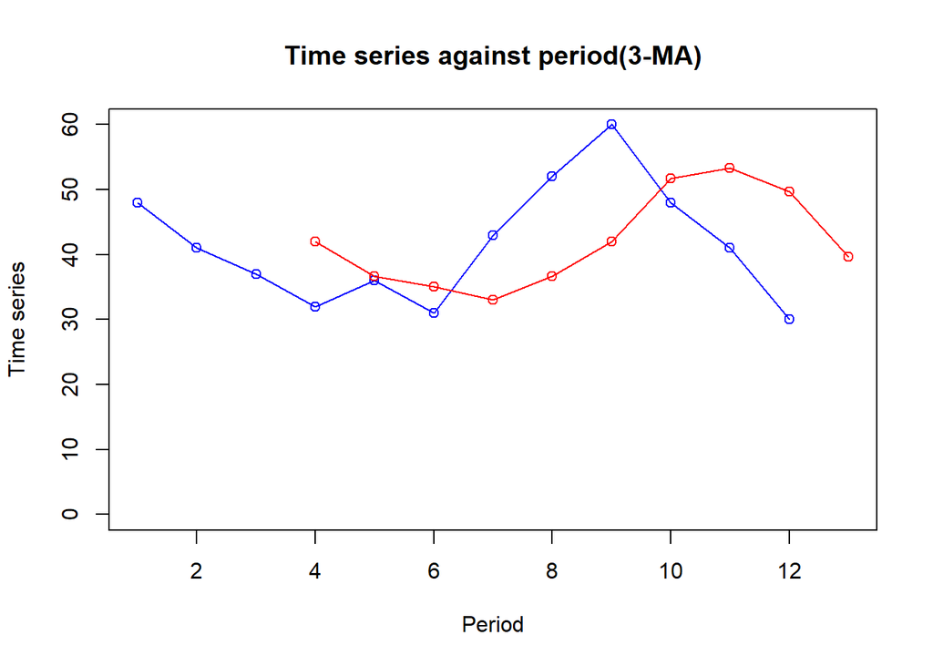

```r
time = read2001$Time_series
n = length(time)
MV_y <- Moving_Average(time, 3)
MV_y[MV_y == 0] <- NA
plot(1:n, time, col = "red", main = "Time series against period(3-MA)", xlab = "Period", ylab = "Time series", xlim = range(1:n, 1:n+1), ylim=range(time,0))
lines(1:n, time, type = "o", col = "blue")
lines(MV_y, type="o", col = "red")
```

Blue line for actual value and red line for forecast value

```r
MV_y[length(time)+1]
```

```
## [1] 39.66667
```

The forecast value for the next period is 39.66667.

## 2. ES(0.8)

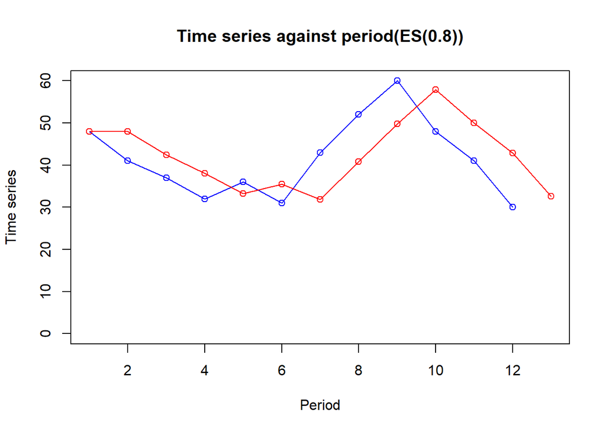

```r
ES_y <- Exponential_Smoothing(time, 0.8)
plot(1:n, time, col = "red", main = "Time series against period(ES(0.8))", xlab = "Period", ylab = "Time series", xlim = range(1:n, 1:n+1), ylim=range(time,0))
lines(1:n, time, type = "o", col = "blue")
lines(ES_y, type="o", col = "red")
```

Blue line for actual value and red line for forecast value

```r
ES_y[length(time)+1]
```

```
## [1] 32.55961
```

The forecast value for the next period is 32.55961.

## 3. EST(0.8, 0.2)

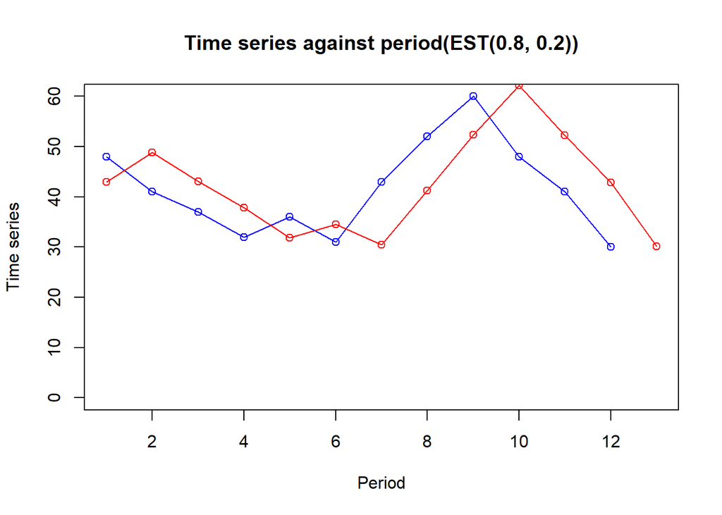

```r
EST_y <- Exponential_Smoothing_with_Trend(time, 0.8, 0.2, 42, 1)
EST_y[EST_y == 0] <- NA
plot(1:n, time, col = "red", main = "Time series against period(EST(0.8, 0.2))", xlab = "Period", ylab = "Time series", xlim = range(1:n, 1:n+1), ylim=range(time,0))
lines(1:n, time, type = "o", col = "blue")
lines(EST_y, type="o", col = "red")
```

Blue line for actual value and red line for forecast value

```r
EST_y[length(time)+1]
```

```
## [1] 30.1546
```

The forecast value for the next period is 30.1546.

## 4. compare three results

```r
Error_M <- matrix(nrow = 3, ncol = 3)
colnames(Error_M) = c("MV", "ES", "EST")
rownames(Error_M) = c("MAD", "MSE", "MAPE")
Error_M[1,1] <- Mean_Absolute_Deviation(time, MV_y, 4)
Error_M[2,1] <- Mean_Square_Error(time, MV_y, 4)
Error_M[3,1] <- Mean_Absolute_Percentage_Error(time, MV_y, 4)
Error_M[1,2] <- Mean_Absolute_Deviation(time, ES_y, 4)
Error_M[2,2] <- Mean_Square_Error(time, ES_y, 4)
Error_M[3,2] <- Mean_Absolute_Percentage_Error(time, ES_y, 4)
Error_M[1,3] <- Mean_Absolute_Deviation(time, EST_y, 4)
Error_M[2,3] <- Mean_Square_Error(time, EST_y, 4)
Error_M[3,3] <- Mean_Absolute_Percentage_Error(time, EST_y, 4)

print(Error_M)
```

```
##             MV        ES       EST
## MAD   10.40741  8.624962  9.196574
## MSE  147.54321 84.716471 98.806668
## MAPE  25.78042 21.208999 22.624023
```

Since ES(0.8) has the least error among three model, we conclude that it is the best forecast method in this Exercise

# Exercise 20.07

```r
read2007 <- read.csv("D:\\Xr20-07.csv")
```

## 1. 3-MA

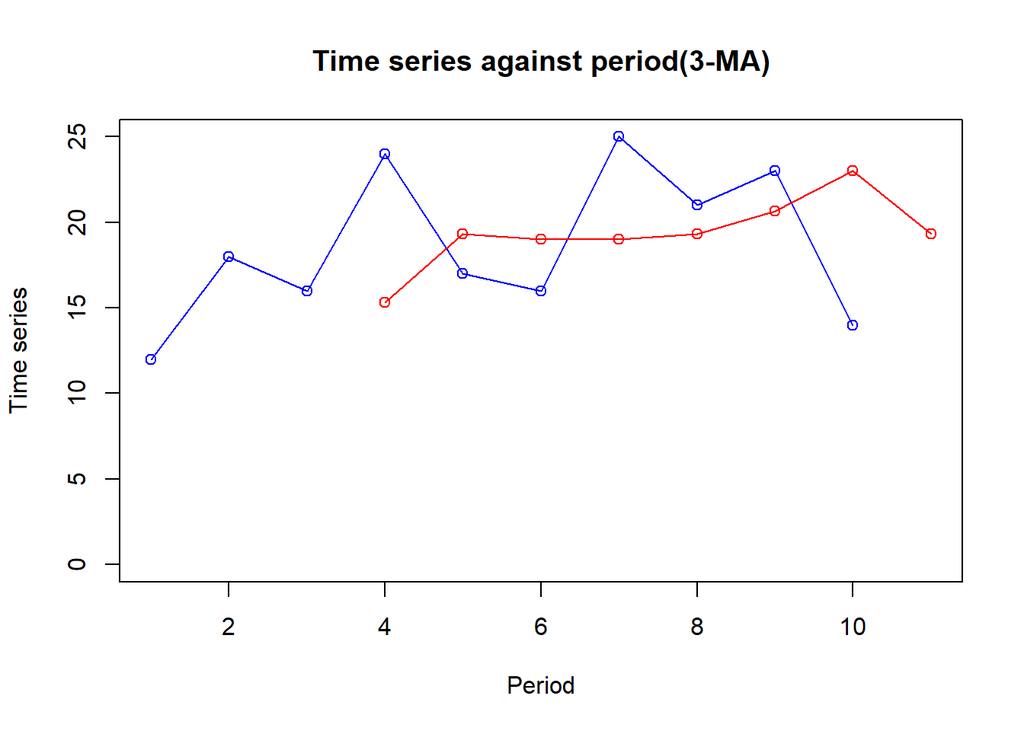

```r
time = read2007$Time_series
n = length(time)
MV_y <- Moving_Average(time, 3)
MV_y[MV_y == 0] <- NA
plot(1:n, time, col = "red", main = "Time series against period(3-MA)", xlab = "Period", ylab = "Time series", xlim = range(1:n, 1:n+1), ylim=range(time,0))
lines(1:n, time, type = "o", col = "blue")
lines(MV_y, type="o", col = "red")
```

Blue line for actual value and red line for forecast value

```r
MV_y[length(time)+1]
```

```
## [1] 19.33333
```

The forecast value for the next period is 19.3333.

## 2. ES(0.8)

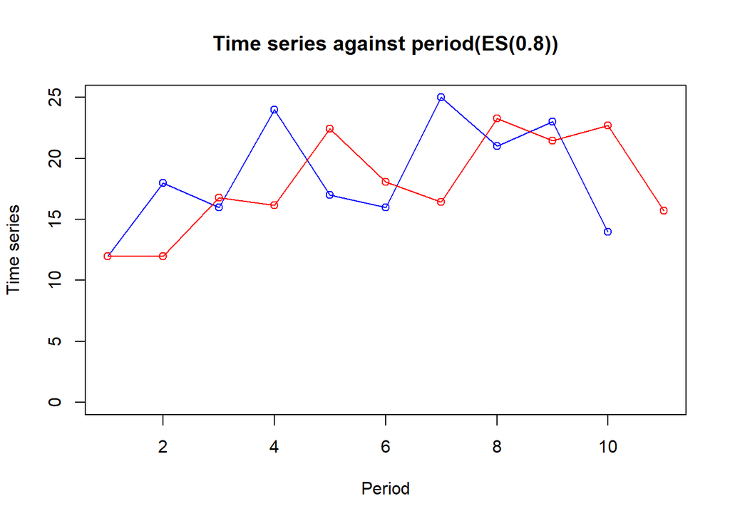

```r
ES_y <- Exponential_Smoothing(time, 0.8)
plot(1:n, time, col = "red", main = "Time series against period(ES(0.8))", xlab = "Period", ylab = "Time series", xlim = range(1:n, 1:n+1), ylim=range(time,0))
lines(1:n, time, type = "o", col = "blue")
lines(ES_y, type="o", col = "red")
```

Blue line for actual value and red line for forecast value

```r
ES_y[length(time)+1]
```

```
## [1] 15.73827
```

The forecast value for the next period is 15.73827.

## 3. EST(0.8, 0.2)

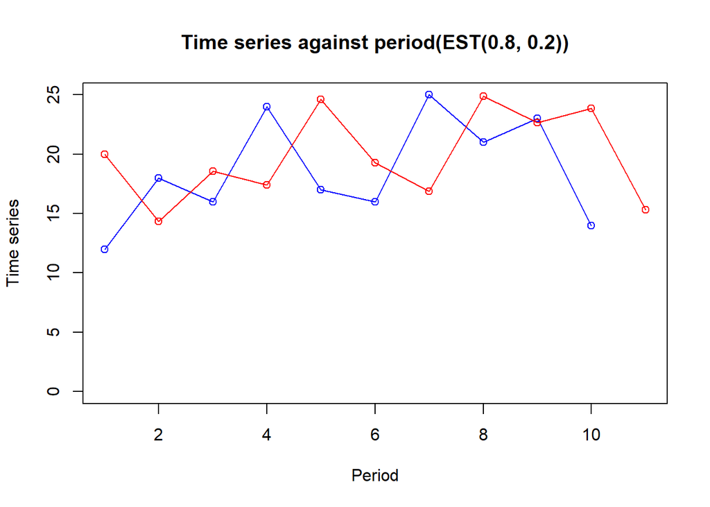

```r
EST_y <- Exponential_Smoothing_with_Trend(time, 0.8, 0.2, 18, 2)
EST_y[EST_y == 0] <- NA
plot(1:n, time, col = "red", main = "Time series against period(EST(0.8, 0.2))", xlab = "Period", ylab = "Time series", xlim = range(1:n, 1:n+1), ylim=range(time,0))
lines(1:n, time, type = "o", col = "blue")
lines(EST_y, type="o", col = "red")
```

Blue line for actual value and red line for forecast value

```r
EST_y[length(time)+1]
```

```
## [1] 15.33831
```

The forecast value for the next period is 15.33831.

## 4. compare three results

```r
Error_M <- matrix(nrow = 3, ncol = 3)
colnames(Error_M) = c("MV", "ES", "EST")
rownames(Error_M) = c("MAD", "MSE", "MAPE")
Error_M[1,1] <- Mean_Absolute_Deviation(time, MV_y, 4)
Error_M[2,1] <- Mean_Square_Error(time, MV_y, 4)
Error_M[3,1] <- Mean_Absolute_Percentage_Error(time, MV_y, 4)
Error_M[1,2] <- Mean_Absolute_Deviation(time, ES_y, 4)
Error_M[2,2] <- Mean_Square_Error(time, ES_y, 4)
Error_M[3,2] <- Mean_Absolute_Percentage_Error(time, ES_y, 4)
Error_M[1,3] <- Mean_Absolute_Deviation(time, EST_y, 4)
Error_M[2,3] <- Mean_Square_Error(time, EST_y, 4)
Error_M[3,3] <- Mean_Absolute_Percentage_Error(time, EST_y, 4)

print(Error_M)
```

```
##             MV       ES       EST
## MAD   4.714286  5.20846  5.673089
## MSE  30.682540 36.01767 41.611052
## MAPE 24.993393 27.37930 30.822339
```

Since 3-MA has the least error among three model, we conclude that it is the best forecast method in this Exercise